# Introdução e Estatística Descritiva

Fernando B. Sabino da Silva

## **Rstudio**

- Faça uma pasta no seu computador onde você deseja manter os arquivos para usar no **Rstudio**.
- Defina o diretório de trabalho nesta pasta: `Session -> Set Working Directory -> Choose Directory` (atalho: Ctrl+Shift+H).
- Torne a alteração permanente definindo o diretório padrão em: `Tools -> Global Options -> Choose Directory`.

## **R** básico

- Cálculos simples:

```r
4.6 * (2 + 3)^4
```

```
## [1] 2875
```

- Defina um objeto (escalar) e o imprima:

```r
a <- 4
a
```

```
## [1] 4
```

- Defina um objeto (vetor) e o imprima:

```r
b <- c(2, 5, 7)
b
```

```
## [1] 2 5 7
```

- Defina uma sequência de números e a imprima:

```r
s <- 1:4
s
```

```
## [1] 1 2 3 4
```

- Nota: Um comando mais flexível para sequências:

```r
s <- seq(1, 4, by = 1)
```

- **R** faz cálculos elemento a elemento:

```r
a * b
```

```
## [1]  8 20 28
```

```r
a + b
```

```
## [1]  6  9 11
```

```r
b ^ 2
```

```
## [1]  4 25 49
```

- Soma e produto de elementos:

```r
sum(b)
```

```
## [1] 14
```

```r
prod(b)
```

```
## [1] 70
```

## Extensões do **R**

- O **R** não precisa ser usado apenas como calculadora ou para atribuição de objetos simples. A sua funcionalidade pode ser estendida atráves de bibliotecas ou pacotes (muito similar a utilização de Plug-ins nos navegadores ou baixar aplicativos no google play). Alguns já vem instalados (automaticamente, by default) no **R** e você precisa apenas carregá-los (como fazemos depois que baixamos um aplicativo no celular e queremos usá-lo, por exemplo).
- Para instalar um novo pacote no **Rstudio** você pode usar o menu: `Tools -> Install Packages`
- Você precisa saber o nome do pacote que deseja instalar. Você também pode fazê-lo através do comando install.packages como abaixo:

```r
install.packages("mosaic")
```

- Uma vez que o pacote esteja instalado, você pode carregá-lo através do comando `library` (ou `require`):

```r
library(mosaic)
```

- Isto carrega o pacote `mosaic` que possuí muitas funções convenientes para este curso (voltaremos a isso mais tarde). Ele também imprime muitas informações sobre as funções que foram alteradas pelo pacote `mosaic`, mas você pode ignorar isto com segurança.

## Ajuda do **R**

- Você pode receber ajuda (help) via `?<command>`:

```r
?sum
```

- Procurando por ajuda:

```r
help.search("plot")
```

- Você pode encontrar um cheat sheet com funções do **R** que usaremos neste curso [aqui](https://drive.google.com/open?id=1678x0r9WNYQJlQPlovgIbwgp1hN5dt5c). Caso o arquivo não apareça, clique com o botão direito em cima do link e escolha `Open link in a new tab`.
- Você pode salvar os comandos que você porventura tenha digitado em um arquivo para uso posterior:
  - Selecione o guia History no painel superior direito no **Rstudio** .
  - Marque os comandos que você deseja salvar.
  - Pressione o botão `To Source`.
- Pratique as suas habilidades básicas em: http://tryr.codeschool.com

## Dados: Exemplos

- Data: [Legibilidade de Anúncios em Revistas](http://lib.stat.cmu.edu/DASL/Datafiles/magadsdat.html)
- Trinta revistas foram classificadas pelo nível educacional de seus leitores.
- Três revistas foram selecionadas **aleatoriamente** de cada um dos seguintes grupos:
  - Grupo 1: maior nível educacional
  - Grupo 2: nível educacional médio
  - Grupo 3: nível educacional mais baixo.
- Seis anúncios foram selecionados **aleatoriamente** de cada uma das nove revistas selecionadas:
  - Grupo 1: [1] Scientific American, [2] Fortune, [3] The New Yorker
  - Grupo 2: [4] Sports Illustrated, [5] Newsweek, [6] People
  - Grupo 3: [7] National Enquirer, [8] Grit, [9] True Confessions
- Logo, os dados contém informações sobre um total de 54 anúncios.

## Objetivos do Capítulo

- Identificar o tipo de variável (por exemplo, numérica ou categórica; discreta ou contínua; ordenada ou não)
- Usar visualizações apropriadas para diferentes tipos de dados (por exemplo, histograma, gráfico de barras (barplot), gráfico de dispersão (scatterplot), boxplot, etc.)
- Criar e interpretar tabelas de contingência e de distribuições de frequência (tabelas uni e bidirecionais - de uma e duas entradas)
- Usar diferentes medidas de tendência central e dispersão e ser capaz de descrever a robustez de diferentes estatística (por exemplo, quando devemos usar cada uma e até que ponto elas podem ser usadas)
- Descrever a forma das distribuições (usando também gráficos como o histograma e o boxplot)

## Exemplo (continuação) - variáveis e formato

- Para cada anúncio (54 casos), os dados abaixo foram observados.
- **Nome das variáveis**:
  - WDS = número de palavras na propaganda
  - SEN = número de frases na propaganda
  - 3SYL = número de palavras com 3 ou mais sílabas no anúncio
  - MAG = revista (1 a 9 como na página anterior)
  - GROUP = nível educacional (1 a 3 como na página anterior)
- Dê uma olhada nos dados usando **Rstudio**:

```r
magAds <- read.delim("C:/Users/fsabino/Desktop/Codes/papers/Introductory_Stat_I/notebook/datasets_ads.txt")
head(magAds)
```

```
##   WDS SEN X3SYL MAG GROUP
## 1 205   9    34   1     1
## 2 203  20    21   1     1
## 3 229  18    37   1     1
## 4 208  16    31   1     1
## 5 146   9    10   1     1
## 6 230  16    24   1     1
```

- Os nomes das variáveis estão na linha superior. Não é permitido começar o nome de uma variável com um dígito, então um `X` foi adicionado em `X3SYL`.

## Tipos de Dados

### Variáveis Quantitativas

- Medições contém valores numéricos.
- Os dados quantitativos geralmente surgem das seguintes maneiras:
  - **Variáveis contínuas**: `medições` de, por exemplo, tempo de espera em uma fila, receitas, preços de ações, etc.
  - **Variáveis discretas**: `contagens` de, por exemplo, palavras em um texto, acessos de um website, números de chegadas em uma fila em uma hora, etc.
- Medidas como esta têm um escala bem definida e no **R** elas são armazenadas como numéricas (**numeric**).

### Variáveis Categóricas/Qualitativas

- A medida é um fator proveniente de um conjunto de determinadas categorias. Exemplos: sexo (masculino/feminino), classe social, escore de satisfação (baixo/médio/alto), etc.
- A medida é normalmente armazenada (o que é altamente recomendável) como um fator (**factor**) no **R**. As categorias possíveis são chamadas de níveis (**levels**). Examplo: os níveis do fator “sexo” são masculino/feminino.
- Fatores têm duas possíveis escalas:
  - **Escala Nominal**: Não há ordenação natural entre os níveis dos fatores. Exemplos: sexo e cor do cabelo.
  - **Escala Ordinal**: Há uma ordenação natural entre os níveis dos fatores. Exemplos: classe social e escore de satisfação. Um fator no **R** pode ter um chamado atributo (**attribute**) atribuído, informando que a escala é ordinal (veja a função ordered()).

# População e Amostra

## Objetivo da Estatística

- O objetivo da Estatística é “dizer algo” sobre a população.
- Tipicamente, isso é feito utilizando as informações de uma amostra aleatória retirada da população de interesse.
- Antes de retirar a amostra podemos ter alguma hipótese sobre a população. A amostra é então analisada como o objetivo de testar esta hipótese.
- O processo de fazer conclusões para uma população com base em uma amostra é chamado de **inferência estatística**.

## Seleção **aleatória**

- Exemplo: Para os dados das revistas:
  - Primeiro nós selecionamos **aleatoriamente** 3 revistas de cada grupo.
  - Na sequência, nós selecionamos, **aleatoriamente**, 6 anúncios de cada revista.
  - Um detalhe importante é que a seleção é feita de maneira completamente **aleatória**, i.e.
    - cada revista dentro de um grupo tem a mesma chance de ser escolhida e
    - cada anúncio dentro de uma revista tem a mesma chance de ser escolhido.
- No que veremos neste curso é fundamental que os dados coletados respeitem o princípio da aleatoriedade. Sempre que utilizarmos a palavra **amostra** daqui em diante, estaremos nos referindo a uma a.a. (amostra aleatória).
- Mais geralmente:
  - Nós temos uma **população** de objetos.
  - Nós escolhemos aleatoriamente $n$ destes objetos, e do $j$-ésimo objeto nós obtemos a medição $y_j$, $j=1,2,\ldots,n$.
  - As medições $y_1, y_2, \ldots, y_n$ são então chamadas de **amostra**. Só uma amostra (que contém $n$ elementos) e não várias amostras.
- Se nós, por exemplo, estivermos medindo a qualidade da água 4 vezes em um ano é uma má ideia coletarmos dados apenas com tempo bom. A amostragem escolhida ao longo do tempo não pode ser influenciada por algo que possa influenciar a medida em si.

# Tabelas de agrupamento e frequência

## Dividir toda a gama de valores em uma série de intervalos: “Binning”

- A função `cut` irá dividir o intervalo de uma variável numérica em vários intervalos de tamanho igual e registrar a qual intervalo pertence cada observação. Por exemplo, para a variável `X3SYL` (o número de palavras com mais de 3 sílabas):

```r
# Antes de 'cortar':
magAds$X3SYL[1:5]
```

```
## [1] 34 21 37 31 10
```

```r
# Após 'cortar' (dividir) em 4 intervalos:
syll <- cut(magAds$X3SYL, 4)
syll[1:5]
```

```
## [1] (32.2,43]     (10.8,21.5]   (32.2,43]     (21.5,32.2]   (-0.043,10.8]
## Levels: (-0.043,10.8] (10.8,21.5] (21.5,32.2] (32.2,43]
```

- O resultado é um fator (`factor`) e os rótulos são os intervalos. Os itens personalizados podem ser atribuídos através do argumento `labels` (rótulos):

```r
labs <- c("poucas", "algumas", "muitas", "demais")
syll <- cut(magAds$X3SYL, 4, labels = labs) # Nota: isso sobreescreverá a variável 'syll' definida acima
syll[1:5]
```

```
## [1] demais  algumas demais  muitas  poucas
## Levels: poucas algumas muitas demais
```

```r
magAds$syll <- syll # Adicionando uma nova coluna ao conjunto de dados
```

## Tabelas

- Para resumir os resultados nós podemos utilizar a função `tally` (contagem) do pacote`mosaic` (relembre que o pacote **deve ser carregado** escrevendo `library(mosaic)` se você ainda não o fez):

```r
tally( ~ syll, data = magAds)
```

```
## syll
##  poucas algumas  muitas  demais
##      26      14      10       4
```

- Em porcentagem:

```r
tally( ~ syll, data = magAds, format = "percent")
```

```
## syll
##  poucas algumas  muitas  demais
##    48.1    25.9    18.5     7.4
```

- Aqui nós usamos uma `fórmula` (caracterizada pelo til) para indicar que nós queremos a variável syll do conjunto de dados `magAds` (sem o til o **R** iria procurar por uma variável global chamada `syll` caso ela exista (se não existir dará certo) e a utilizaria ao invés da que queremos).

## 2 fatores: Tabulação Cruzada

- Para fazer uma tabela da combinação de dois fatores nós utilizamos a função `tally` novamente:

```r
tally( ~ syll + GROUP, data = magAds)
```

```
##          GROUP
## syll       1  2  3
##   poucas   8 11  7
##   algumas  4  2  8
##   muitas   3  5  2
##   demais   3  0  1
```

- Frequências relativas (em porcentagem) por coluna:

```r
tally( ~ syll | GROUP, data = magAds, format = "percent")
```

```
##          GROUP
## syll         1    2    3
##   poucas  44.4 61.1 38.9
##   algumas 22.2 11.1 44.4
##   muitas  16.7 27.8 11.1
##   demais  16.7  0.0  5.6
```

- A tabela acima mostra, por exemplo, qual a porcentagem de anúncios no grupo 1 que tem ‘poucas’, ‘algumas’, ‘muitas’ ou ‘demais’ com mais de 3 sílabas.

# Gráficos

## Gráfico de barras

- Para criar um gráfico de barras com os dados da tabela nós usamos a função `gf_bar` do pacote `mosaic`. Para cada nível do fator uma caixa é desenhada com a altura proporcional a frequência (contagem) daquele nível.

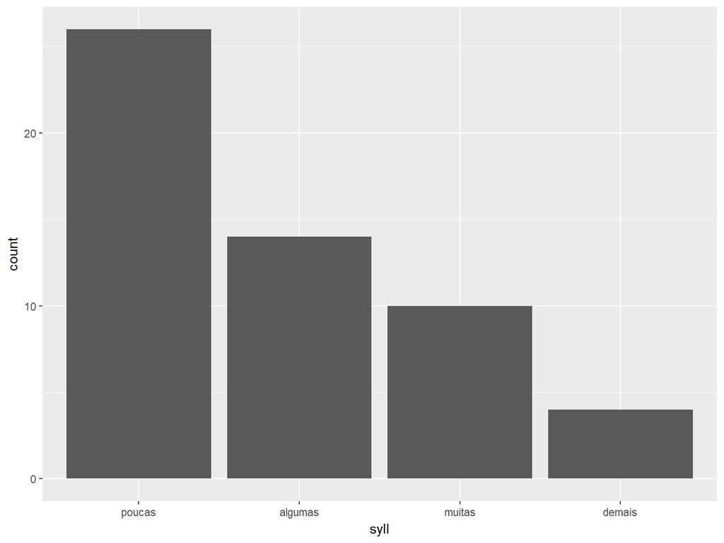

```r
gf_bar( ~ syll, data = magAds)
```

- O gráfico de barras também pode ser dividido por grupo:

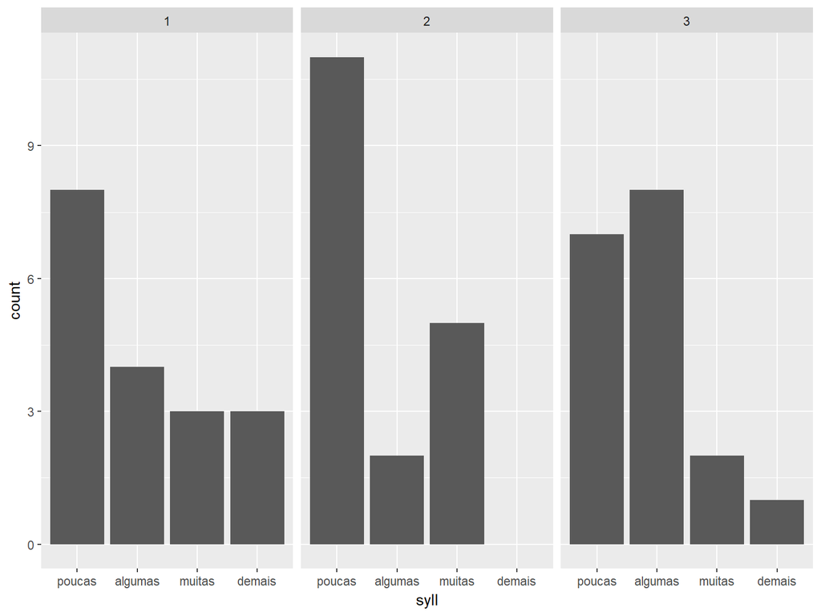

```r
gf_bar( ~ syll | GROUP, data = magAds)
```

## Os dados de Ericksen

- Descrição dos dados: [Ericksen 1980 U.S. Census Undercount](http://www.rdocumentation.org/packages/car/functions/Ericksen).
- Este conjunto de dados contém as seguintes variáveis:
  - `minority`: Percentual de negros ou hispânicos.
  - `crime`: Taxa de crimes graves por 1000 indivíduos na população.
  - `poverty`: Percentual de pobres.
  - `language`: Percentual com dificuldade em falar ou escrever Inglês.
  - `highschool`: Percentual com idade igual ou superior a 25 anos que não terminou o ensino médio.
  - `housing`: Percentual de habitação em pequenos edifícios de unidades múltiplas.
  - `city`: Um fator com níveis: `city` (cidade principal) ou `state` (estado or estado-resto).
  - `conventional`: Percentual de domicílios contados por enumeração pessoal convencional.
  - `undercount`: Estimativa preliminar de subentendimento percentual.
- Os dados de Ericksen têm 66 linhas/observações e 9 colunas/variáveis.
- As observações são medidas em 16 grandes cidades, as partes restantes dos estados em que essas cidades estão localizadas, e os outros estados dos EUA.

```r
Ericksen <- read.delim("C:/Users/fsabino/Desktop/Codes/papers/Introductory_Stat_I/notebook/datasets_Ericksen.txt")
head(Ericksen)
```

```
##   minority crime poverty language highschool housing  city conventional
## 1     26.1    49      19      0.2         44     7.6 state            0
## 2      5.7    62      11      1.7         18    23.6 state          100
## 3     18.9    81      13      3.2         28     8.1 state           18
## 4     16.9    38      19      0.2         44     7.0 state            0
## 5     24.3    73      10      5.0         26    11.8 state            4
## 6     15.2    73      10      1.2         21     9.2 state           19
##   undercount
## 1      -0.04
## 2       3.35
## 3       2.48
## 4      -0.74
## 5       3.60
## 6       1.34
```

- Quer fazer um histograma para a taxa de criminalidade - como?

## Histograma (usado para variáveis quantitativas)

- Como fazer um histograma para alguma variável `x`:
  - Divida o intervalo do valor mínimo de `x` para o valor máximo de`x` em um número apropriado de sub-intervalos de tamanho igual.
  - Desenhe uma caixa em cada sub-intervalo, sendo a altura proporcional ao número de observações no subintervalo.
- Histograma de taxas de criminalidade para os dados de Ericksen

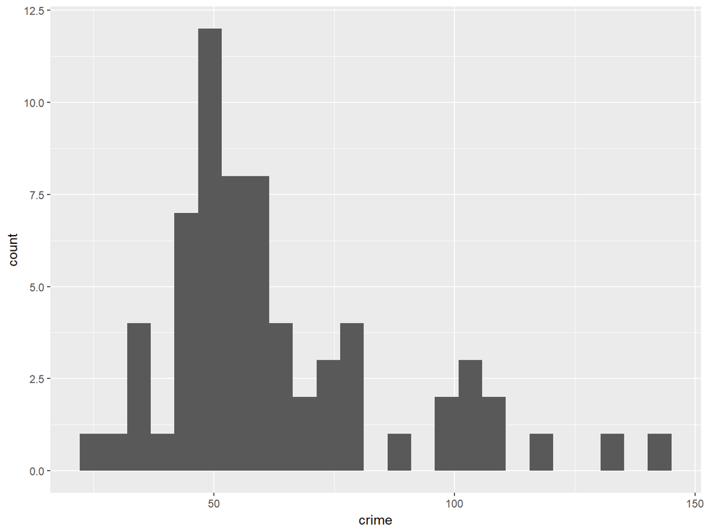

```r
gf_histogram( ~ crime, data = Ericksen)
```

Questão: Explique como o histograma é construído.

# Resumo de Variáveis Quantitativas

## Medidas de centro dos dados (tendência central/posição): Média, Mediana e Moda

- Retornemos ao exemplo de anúncios da revista (`WDS` = número de palavras no anúncio). Uma série de resumos numéricos para `WDS` pode ser encontrada usando a função `favstats`:

```r
favstats( ~ WDS, data = magAds)
```

```
##  min Q1 median  Q3 max mean sd  n missing
##   31 69     96 202 230  123 66 54       0
```

- Os valores observados da variável `WDS` são $y_1=205$, $y_2=203,\ldots,y_n=208$, onde existe um total de $n=54$ valores. Conforme definido anteriormente, isso constitui uma **amostra**.
- 123 é a **média** da amostra, que é calculada por
  $$\bar{y}=\frac{1}{n}\sum_{i=1}^n y_i$$
  Nós chamamos $\bar{y}$ de **média amostral**.

```r
mean(y)
```

```
## [1] 123
```

- A média é o ponto de equilíbro dos dados.
- A média é sensível a valores extremos.
- **mediana** = 96 é o percentil 50, i.e. o valor que divide a amostra em 2 grupos de igual tamanho.

```r
median(y)
```

```
## [1] 96
```

```
* Veja como calcular a mediana (e qualquer outro percentil) na página 75 do livro "Estatística Aplicada à Administração e Economia" (está na página do curso no moodle). Resolva os exemplos das páginas 75-77.
```

- A **mediana** é robusta a valores extremos.
- É uma medida mais apropriada quando trabalhamos com dados assimétricos.
- Uma propriedade importante da **média** e da **mediana** é que elas têm a mesma unidade de medida que as observações.
- **moda** = 208 é o valor mais frequente do banco de dados.

```r
names(sort(-table(y)))[1]
```

```
## [1] "208"
```

- Exercício: Faça o exercício 1 da página 24 do livro Estatística (Costa Neto). A resposta está na página 258.

## Medidas de variabilidade: amplitude, amplitude interquartílica, variância, desvio padrão, e coeficiente de variação

- Nós queremos saber “Quanto as observações estão desviadas do seu valor central?”
  - Ao olhar os dados e gráficos podemos ter uma sensação disto.
  - Porém, é comum estarmos interessados em um número para que possamos comparar as distribuições amostrais.
- **Amplitude** é a diferença entre o maior (máximo) e o menor (mínimo) valor.
  - Ela só usa dois valores para o seu cálculo, isto é, não leva todos em consideração.
  - Como trabalhamos com uma amostra, a amplitude que encontraremos será a amostral, isto é, em geral, temos uma subestimativa da verdadeira amplitude.
- A **amplitude interquartílica** é a diferença entre os valores do terceiro quartil e do primeiro quartil, isto é, $Q_{3} - Q_{1}$.
  - Ela utiliza 50% dos valores para o seu cálculo.
- The **variância (empírica)** é a média dos desvios quadrados em relação à média:
  $$s^2=\frac{1}{n-1}\sum_{i=1}^n (y_i-\bar{y})^2.$$
- **sd** $=$ **desvio padrão** $= s=\sqrt{s^2}$.
- Nota: Por exemplo, se as observações são medidas em metros, a unidade de medida da **variância** será $\text{metro}^2$ o que usualmente dificulta a interpretação. Por outro lado, o **desvio padrão** tem a mesma unidade de medida das observações.
- O **coeficiente de variação** (CV) é uma medida adimensional que serve para comparar a variabilidade de variáveis medidas em diferentes unidade de medida ou cujas médias e desvios-padrão sejam muito diferentes (mesma unidade de medida e grandezas muito diferentes). Portanto, o **CV** é uma medida de variabilidade relativa, ao contrário das demais vistas que são medidas de variabilidade absolutas. Define-se o CV como a razão entre o desvio-padrão e a média (frequentemente é multiplicado por 100% para ser representado como uma variação percentual).

$$CV = \frac{s}{\bar{x}}$$
* Exercício: Faça o exercício 4 da página 32 do livro Estatística (Costa Neto). O objetivo do exercício é treinar o cálculo. A resposta está na página 258.

## Cálculo da média, mediana, amplitude interquartílica e desvio-padrão usando a função favstats do pacote mosaic

- Medidas Resumo de `WDS`:

```r
favstats( ~ WDS, data = magAds)
```

```
##  min Q1 median  Q3 max mean sd  n missing
##   31 69     96 202 230  123 66 54       0
```

**Exercício**: Interprete os resultados acima.

## Uma palavra sobre terminologia

- **Desvio padrão**: uma medida de variabilidade de uma variável na amostra (ou população).
- **Erro padrão**: uma medida de variabilidade de uma estimativa (um particular valor de uma função da amostra). Por exemplo, uma medida de variabilidade da média amostral.

## Uma regra empírica (veremos detalhes mais à frente)

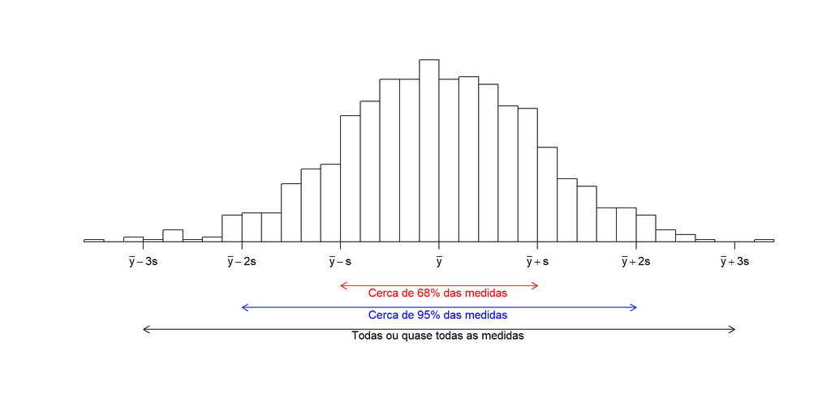

Se o histograma com base na amostra parece uma função em forma de sino, então

- cerca de 68% das observações estão entre $\bar{y}-s$ e $\bar{y}+s$.
- acerca de 95% das observações estão entre $\bar{y}-2s$ e $\bar{y}+2s$.
- Todas ou quase todas as observações (99.7%) estão entre $\bar{y}-3s$ e $\bar{y}+3s$.

## Mediana, quartis e amplitude interquartílica

Recordando

```r
favstats( ~ WDS, data = magAds)
```

```
##  min Q1 median  Q3 max mean sd  n missing
##   31 69     96 202 230  123 66 54       0
```

- 50-percentil = 96 é a **mediana** e é uma medida de tendência central/posição (centro dos dados).
- 0-percentil = 31 é o valor **mínimo**.
- 25-percentil = 69 é o **primeiro quartil** ou **quartil inferior** (Q1). Mediana dos 50% menores valores.
- 75-percentil = 201.5 é o **terceiro quartil** ou **quartil superior** (Q3). Mediana dos 50% maiores valores.
- 100-percentil = 230 é o valor **máximo**.
- **Amplitude Interquartílica (IQR)**: uma medida de variabilidade dada pela diferença entre o quartil superior e o quartil inferior: 201.5 - 69 = 132.5.

# Mais gráficos

## Box plots

Como desenhar um box plot:

- Box:
  - Calcule a mediana, e os quartis inferior e superior.
  - Trace uma linha na mediana e desenhe uma caixa entre os quartis superior e inferior.
  - Calcule a amplitude interquartílica e a chame de IQR.
  - Calcule os seguintes valores:
    - L = quartil inferior - 1.5*IQR
    - U = quartil superior + 1.5*IQR
  - Desenhe uma linha ligando o quartil inferior até a menor medida que seja maior do que *L*.
  - Similarmente, desenhe uma linha ligando o quartil superior até a maior medida que seja inferior a *U*.
  - Regras de decisão
  - Max($X_\left[1 \right]$, L)
  - Min($X_\left[n \right]$, U)
- Outliers: Observações com valor menor do que *L* ou maior do que *U* são desenhadas como círculos.

*Nota: As caixas são fechadas (em inglês, as extremidades são chamadas de “Whiskers”) no mínimo e no máximo das observações que não são consideradas outliers.*

### Boxplot para os dados de Ericksen

Boxplot das taxas de pobreza separadamente para cidados e estados (variável `city`):

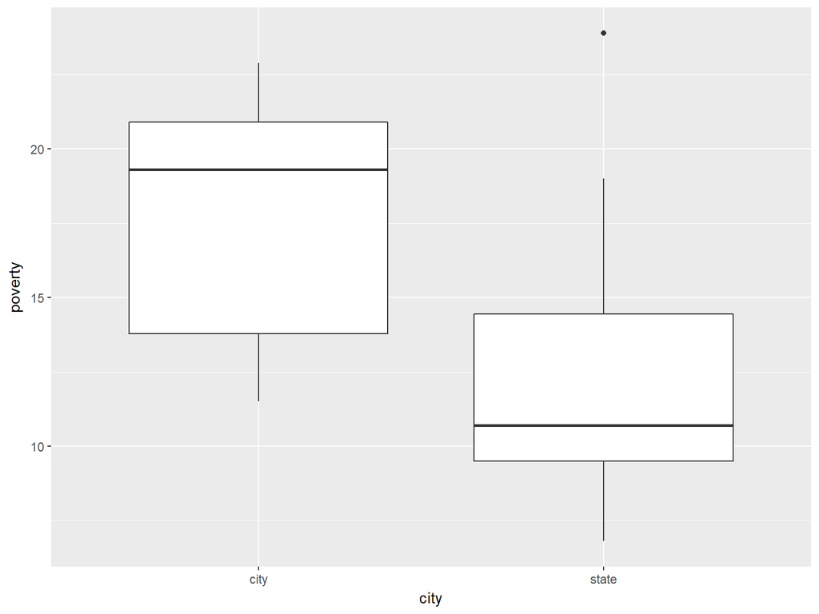

```r
gf_boxplot(poverty ~ city, data = Ericksen)
```

- Parece haver mais pobreza nas cidades.
- Um único estado difere notoriamente dos outros com alta taxa de pobreza.

## 2 variáveis quantitativas variables: Gráfico de dispersão (“Scatter plot”)

Para duas variáveis quantitativas, um gráfico frequentemente utilizado é o de dispersão:

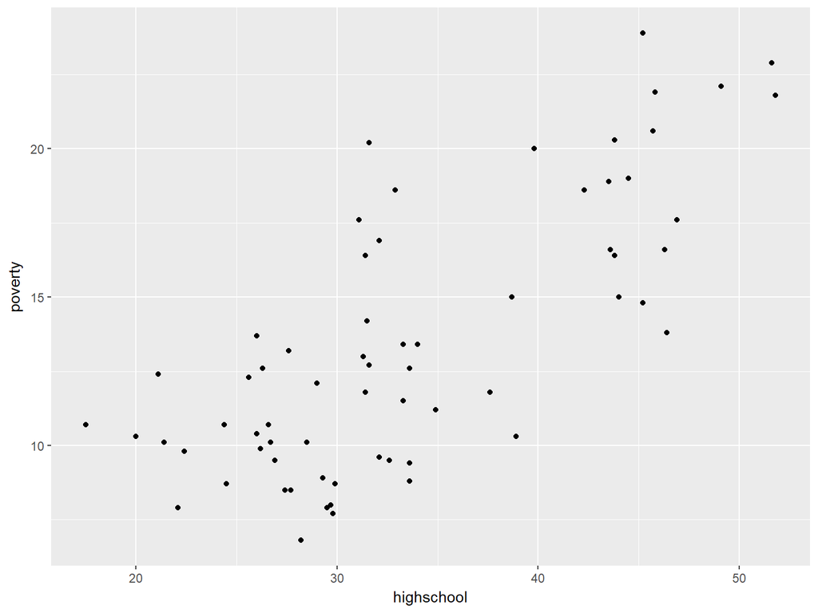

```r
gf_point(poverty ~ highschool, data = Ericksen)
```

Isto pode ser colorido ou dividido de acordo com o valor de `city`:

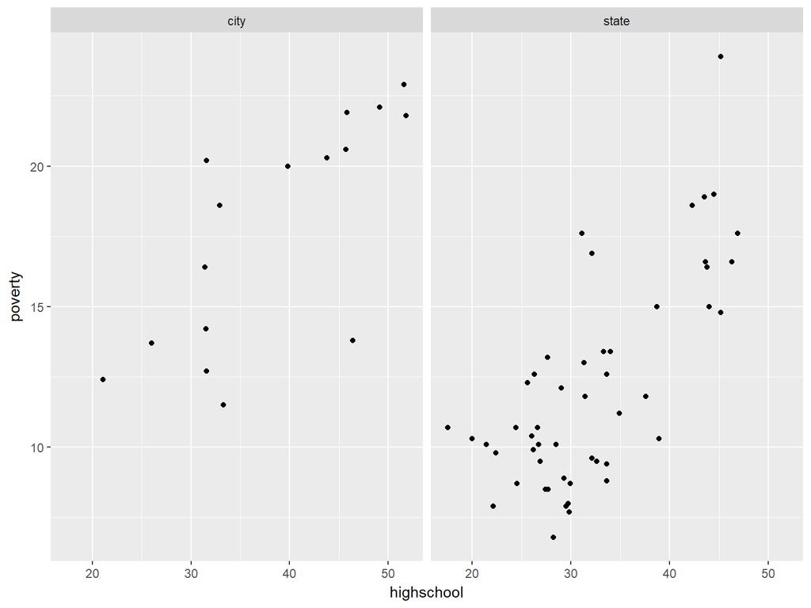

```r
gf_point(poverty ~ highschool | city, data = Ericksen)
```

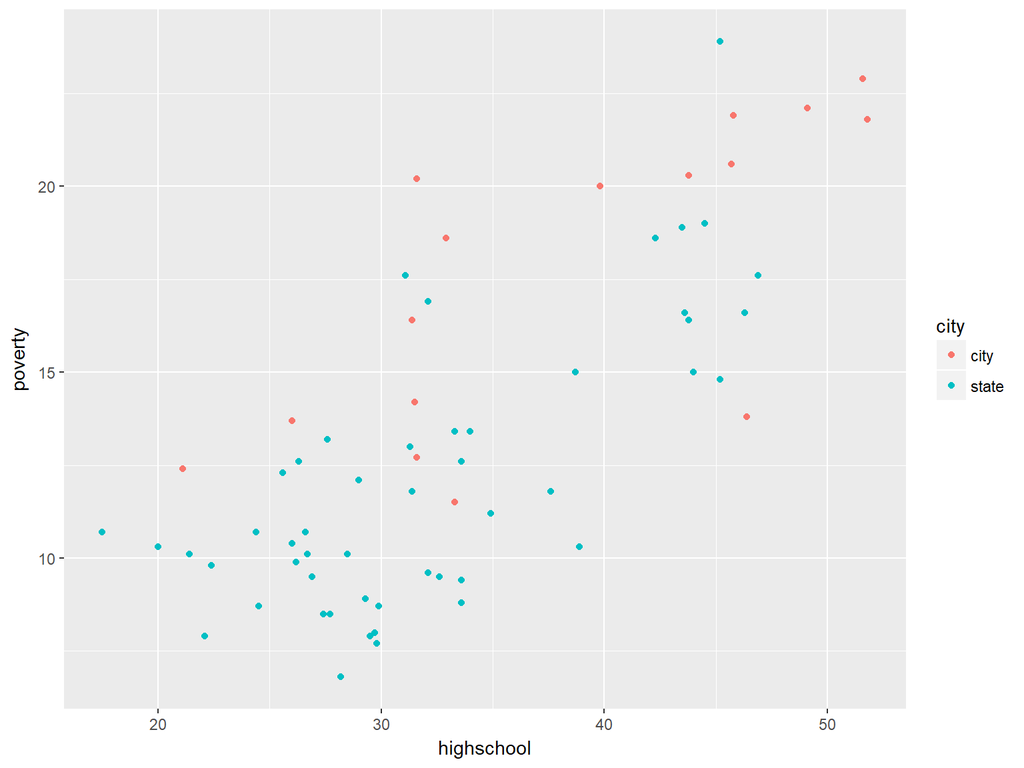

```r
gf_point(poverty ~ highschool, col = ~city, data = Ericksen)
```

Se nos quisermos adicionar uma linha de regressão (uma equação da reta neste caso) nós podemos usar as funções abaixo:

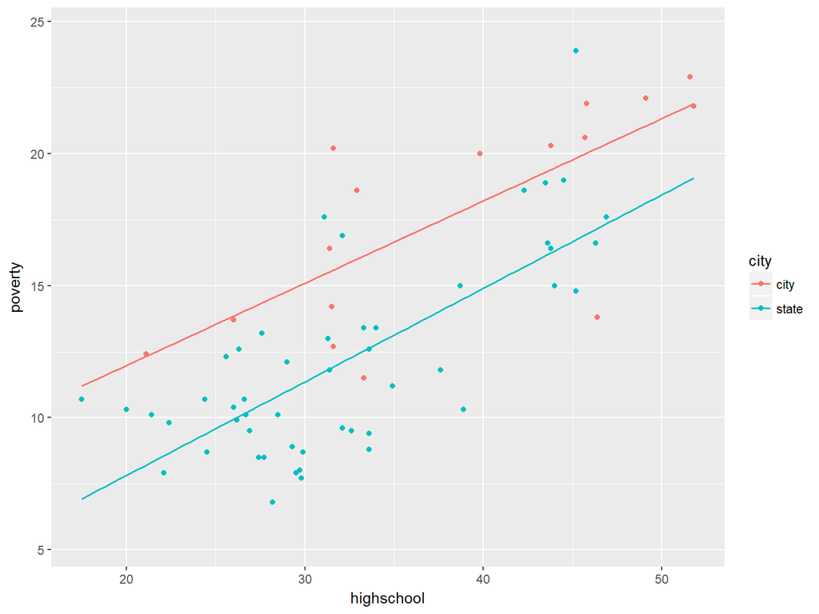

```r
gf_point(poverty ~ highschool, col = ~city, data = Ericksen) %>% gf_lm()
```

## Assimetria e Curtose

- O conteúdo pode ser estudado nas páginas 30-31 do livro “Estatística” (Costa Neto).

## Covariância e Correlação

```
* O conteúdo pode ser estudado nas páginas 98-104 do livro "Estatística Aplicada à Administração e Economia" (edição que está no moodle).
```

# Apêndice

## Recodificando variáveis

- A função `factor` converterá diretamente um vetor em uma variável qualitativa (escala nominal). Por exemplo:

```r
head(magAds$GROUP)
```

```
## [1] 1 1 1 1 1 1
```

```r
class(magAds$GROUP)
```

```
## [1] "integer"
```

```r
f <- factor(magAds$GROUP)
class(f)
```

```
## [1] "factor"
```

```r
# magAds$GROUP <- f
# head(magAds$GROUP)
```

# Apontar e clicar no gráfico

## `mplot`

- Se os pacotes `mosaic` e `manipulate` forem instalados e estiverem carregados, nós podemos construir gráficos usando a função `mplot` simplesmente apontando e clicando.
- Usando `mplot` você pode fazer alterações pressionando o botão de configurações (uma roda dentada) no canto superior esquerdo da janela gráfica.

```r
mplot(Ericksen)
```

- No final, você pode pressionar “Mostrar expressão” (Show expression) para obter o código.